# Cocao Analysis

## Import CSV

```r
full_data <- read_csv('~/Downloads/flavors_of_cacao.csv')
```

## View dataset columns

You can see the column name include space and line break. If we don’t clean that it might cause error in ggplot.

```
## [1] "Company \n(Maker-if known)"        "Specific Bean Origin\nor Bar Name"
## [3] "REF"                               "Review\nDate"
## [5] "Cocoa\nPercent"                    "Company\nLocation"
## [7] "Rating"                            "Bean\nType"
## [9] "Broad Bean\nOrigin"
```

### Clean columns name format

```r
# Remove and replace spaces and line breaks
names(full_data) <- tolower(gsub(pattern = '[[:space:]+]', '_', names(full_data)))

# View the new column names
names(full_data)
```

```
## [1] "company _(maker-if_known)"        "specific_bean_origin_or_bar_name"
## [3] "ref"                              "review_date"
## [5] "cocoa_percent"                    "company_location"
## [7] "rating"                           "bean_type"
## [9] "broad_bean_origin"
```

### Explain the columns in Chinese

1. “company_maker”: 制造巧克力的公司或品牌的名称。
2. “specific_bean_origin_or_bar_name”: 指定可可豆的原产地或巧克力棒的名称。这个列可能包含有关可可豆种类或巧克力产品的其他特定信息。
3. “ref”: 参考编号，可能是与巧克力产品或数据相关的参考编号。
4. “review_date”: 评论日期，指示对巧克力进行评价的日期。
5. “cocoa_percent”: 可可含量，表示巧克力中可可固体的百分比。
6. “company_location”: 制造公司的所在地或总部所在地。
7. “rating”: 对巧克力产品的评级或评分。
8. “bean_type”: 可可豆的类型或品种。
9. “broad_bean_origin”:可可豆的产地或原产地，指示制作巧克力所用可可豆的来源。

## Explore the data

Just find anything I interested

### Data collection date

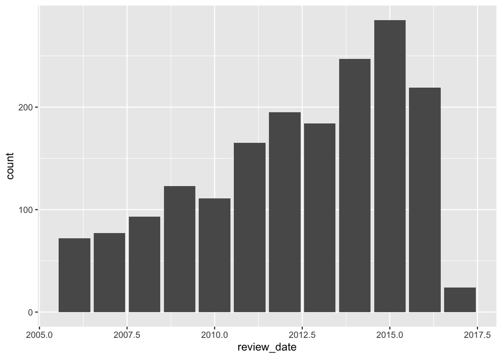

## Cocoa percentage

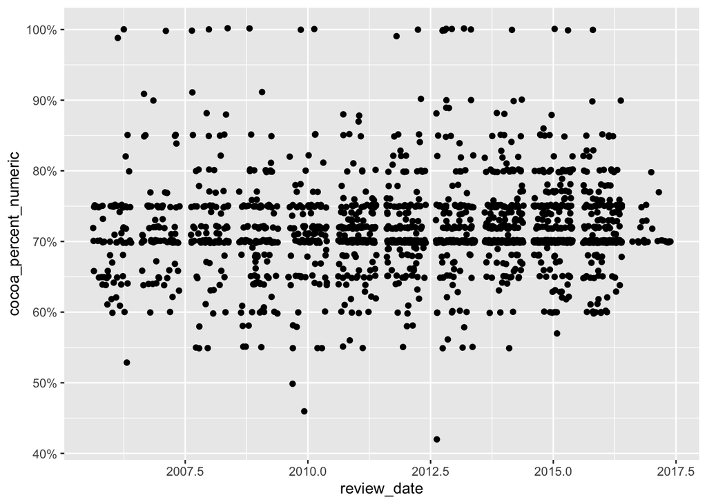

```r
# 将百分比字符串转换为数值
full_data$cocoa_percent_numeric <- as.numeric(sub("%", "", full_data$cocoa_percent)) / 100

# 设置刻度间距为每隔10%显示一个标签
ggplot(data = full_data) +
  geom_jitter(mapping = aes(x = review_date, y = cocoa_percent_numeric)) +
  scale_y_continuous(breaks = seq(0, 1, by = 0.1), labels = scales::percent)
```

## broad_bean_origin 统计

“specific_bean_origin_or_bar_name” 是具体地点，broad_bean_origin 对于的地点相对广泛，更利于统计,但是数据仍然需要进一步清洗

```r
# 假设您的数据框名为df，列名为specific_bean_origin_or_bar_name
df_counts <- full_data %>%
  group_by(broad_bean_origin) %>%
  summarise(count = n())

# 查看计数结果
print(df_counts)
```

```
## # A tibble: 101 × 2
##    broad_bean_origin         count
##    <chr>                     <int>
##  1 Africa, Carribean, C. Am.     1
##  2 Australia                     3
##  3 Belize                       49
##  4 Bolivia                      57
##  5 Brazil                       58
##  6 Burma                         1
##  7 Cameroon                      1
##  8 Carribean                     8
##  9 Carribean(DR/Jam/Tri)         1
## 10 Central and S. America        4
## # ℹ 91 more rows
```

```r
# 假设您的数据框名为df，列名为specific_bean_origin_or_bar_name
ref_counts <- full_data %>%
  group_by(`company _(maker-if_known)`) %>%
  summarise(count = n())

# 查看计数结果
print(ref_counts)
```

```
## # A tibble: 416 × 2
##    `company _(maker-if_known)` count
##    <chr>                       <int>
##  1 A. Morin                       23
##  2 AMMA                            5
##  3 Acalli                          2
##  4 Adi                             4
##  5 Aequare (Gianduja)              2
##  6 Ah Cacao                        1
##  7 Akesson's (Pralus)              3
##  8 Alain Ducasse                   5
##  9 Alexandre                       4
## 10 Altus aka Cao Artisan          10
## # ℹ 406 more rows
```

## Try rworldmap

learning YANGYA’s code, It’s not teach in coursera’s course.

```r
omap <- group_by(full_data,broad_bean_origin)
omap1 <- summarise(omap,broad_bean_origin)
```

```r
map2 <- joinCountryData2Map(omap1,joinCode="NAME",nameJoinColumn = "broad_bean_origin")
```

```
## 1555 codes from your data successfully matched countries in the map
## 240 codes from your data failed to match with a country code in the map
## 196 codes from the map weren't represented in your data
```

[figure not shown]

```r
mapCountryData(map2,  mapTitle = "Cocao Origin Distribution", colourPalette = "negpos8")
```

## Company location

This value means where the chocolate manufacture company base at.

```r
cmap <- group_by(full_data,company_location)
cmap1 <- summarise(cmap,count=n())
map3 <- joinCountryData2Map(cmap1,joinCode="NAME",nameJoinColumn = "company_location")
```

```
## 51 codes from your data successfully matched countries in the map
## 9 codes from your data failed to match with a country code in the map
## 192 codes from the map weren't represented in your data
```

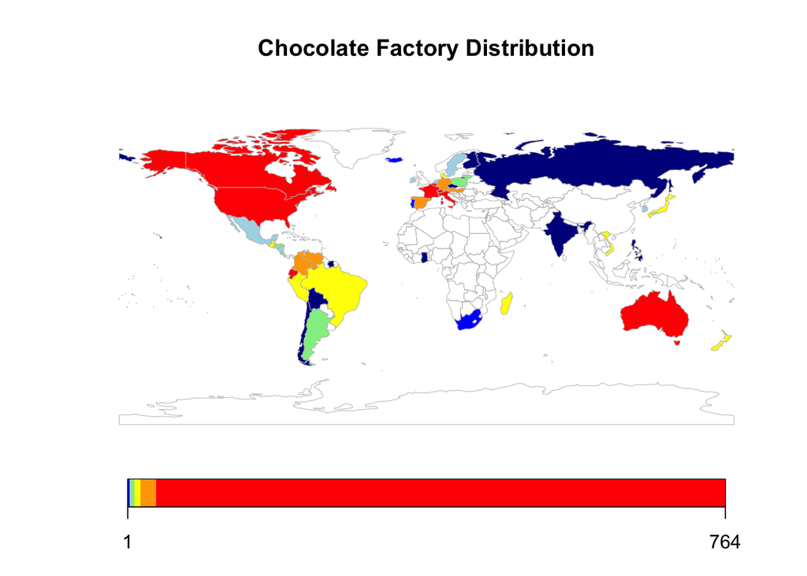

```r
mapCountryData(map3,nameColumnToPlot = "count", mapTitle = "Chocolate Factory Distribution", colourPalette = "negpos8")
```